# O impacto dos gastos públicos nos resultados nacionais de inovação

Uma análise comparativa dos países membros e associados do Mercosul através de dados em painel

Matheus Bispo de Pinho

2024-09-09

# Resumo

O presente trabalho buscou identificar se os investimentos públicos em Pesquisa e Desenvolvimento (P&D) possuíram efeitos significativos nos resultados dos processos de inovação realizados nos países membros e associados ao Mercosul no período entre 2000 e 2020. Essa avaliação se mostrou relevante ao passo que a inovação é apresentada como principal fator do crescimento econômico sustentável. Com esse objetivo dois outputs tradicionais do processo de inovação - número de patentes e publicações acadêmicas - foram utilizados como variáveis dependentes.

Para tal foi construído painel de dados com base em múltiplas fontes de dados, compatibilizadas com base nas informações do método de cálculo dos indicadores e dos dicionários de dados. O painel base - não balanceado - foi imputado de forma a se suprir as observações ausentes e gerar um painel balanceado.

Os paineis balanceados e não balanceados foram submetidos a alguns métodos econométricos - Mínimos Quadrados Ordinários (MQO), Efeitos Fixos controlados com variáveis Dummy, Modelo de Efeitos Fixos e Modelo de Efeitos Aleatórios.

Os resultados obtidos nos quatro métodos foram comparados com base no painel de origem. O resultado foi que as variáveis mais relevantes para os resultados foram pib per capita e o número de pesquisadores por milhão de habitantes (proxy da força de trabalho envolvida em inovação). Os gastos em P&D, instrumento tradicional das políticas públicas de inovação, possuíram efeeito significativo, em maior nível os gastos privados e em um segundo nível os gastos públicos.

# Introdução

## Objeto

O presente trabalho possui como objeto de investigação os gastos públicos em pesquisa e desenvolvimento no contexto da América do Sul, notadamente dos países membros do Mercosul - Argentina, Brasil, Paraguai, Uruguai e Venezuela - e dos associados ao bloco - Bolívia, Chile, Colômbia, Equador e Peru. Analisando o impacto desses gastos nos resultados dos processos de inovação - apresentados aqui através de duas variáveis d(Número de patentes e Número de publicações acadêmicas).

A tabela a seguir apresenta a evolução das variáveis dependentes - “Número de patentes” e “Número de publicações acadêmicas” com base em painel não imputado, possuindo valores ausentes.

## Evolução do número de patentes por país

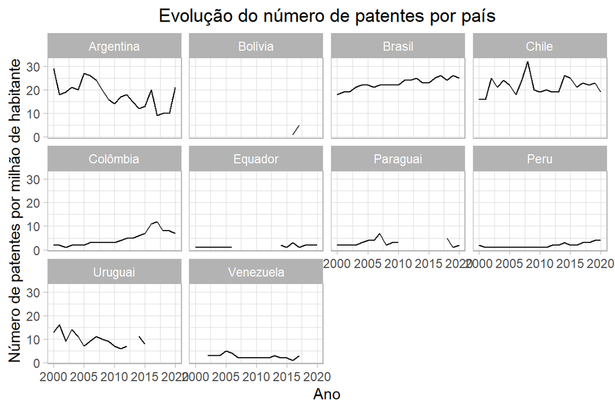

## Evolução publicações acadêmicas por milhão de habitantes

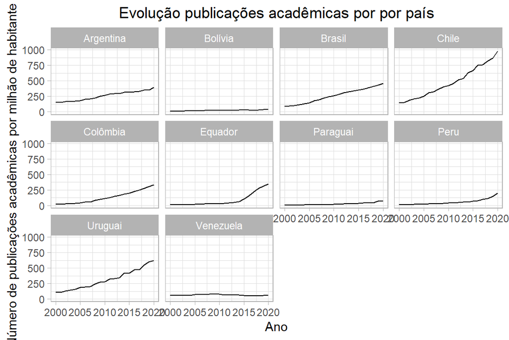

## Objetivos

O principal objetivo do trabalho é responder à seguinte questão de pesquisa, “Os investimentos públicos em Pesquisa e Desenvolvimento (P&D) possuíram efeitos significativos nos resultados dos processos de inovação realizados nos países membros e associados ao Mercosul no período entre 2000 e 2020?”

## Contexto

Consta do Manual de Oslo que “apenas recentemente surgiram políticas de inovação como um amálgama de políticas de ciência e tecnologia e política industrial. Seu surgimento sinaliza um crescente reconhecimento de que o conhecimento, em todas as suas formas, desempenha um papel crucial no progresso econômico, que a inovação está no âmago dessa “economia baseada no conhecimento”, que a inovação é um fenômeno muito mais complexo e sistêmico do que se imaginava anteriormente. As abordagens sistêmicas à inovação deslocam o foco das políticas, dando ênfase à interação das instituições, observando processos interativos, tanto na criação do conhecimento, como em sua difusão e aplicação. Cunhou-se o termo “Sistema Nacional de Inovações” para este conjunto de instituições e fluxos de conhecimento”

Cassiolato e Lastres (2000) apresentam que a noção de sistemas de inovação se baseia no argumento de que mudanças técnicas são tanto determinantes quanto determinadas pelo ambiente institucional em um processo interativo e que a análise de distintos sistemas nacionais de inovação é fundamental para entender por que o dinamismo tecnológico ocorre de forma mais rápida e eficiente em alguns países do que em outros.

A diversidade é conceito central nos sistemas de inovação, cada país possui um conjunto de fatores que influenciam seus processos de inovação. Cassiolato e Lastres (2000) ao abordar os estudos realizados no âmbito da América Latina e no Caribe apresentaram que a literatura reiterou alguns desses fatores, comuns aos países em desenvolvimento, como a vulnerabilidade macroeconômica, política, institucional e financeira, além dos cenários de hiperinflação, alta dívida externa e altas taxas de juros.

Em linha com o crescimento da economia baseada no conhecimento e no reconhecimento da inovação como um fenômeno relevante e que perpassa a atuação de múltiplos atores, um amplo conjunto de países estabeleceram políticas de inovação, orientadas pelos governos, mas com relevante participação de atores privados.

No ano de 2020 foi institucionalizada no Brasil a Política Nacional de Inovação (PNI), com intuito de “ser uma base para a organização das atividades do Estado relacionadas ao apoio à inovação”. No ano de 2023, foi aprovado na Argentina o “Plan Nacional de Ciencia, Tecnología e Innovación 2030” com objetivo de “impulsionar a geração e gestão do conhecimento para a inovação social e produtiva inclusiva e sustentável”. Essas duas iniciativas se inserem em um amplo conjunto de ações implementadas em países sul-americanos nos últimos anos, o que demonstra a crescente preocupação com o tema da inovação.

Esse processo é especialmente relevante devido à sua influência para o crescimento econômico. No contexto da América Latina ressalta-se dado apresentado no relatório “Why Does Latin America Underperform?” (G30, 2023) sobre o crescimento da região entre 1990 e 2019, com um crescimento médio do produto per capita de 1,73% ao ano, pouco acima do desempenho das economias avançadas (1,68% a.a.) e abaixo da Ásia Emergente (3,90% a.a.). Nessa linha, o avanço do conhecimento tecnológico foi identificado como o fator mais importante para a produtividade a longo prazo e o crescimento econômico (Grubler et al., 1999 apud Greenacre et al, 2012).

Para Pacheco e Almeida (2013) há um amplo e crescente consenso, público e privado, da relevância da inovação tanto para a competitividade de cada empresa brasileira, como para o aumento da produtividade em geral. A inovação tem essa dupla faceta — é relevante em termos micro e em termos macroeconômicos. (Pachedo e Almeida, 2013).

A questão da inovação já foi trabalhada sob diversas óticas ao longo dos anos. Contribuição proeminente foi realizado por Schumpeter (1997), um dos grandes expoentes da pesquisa em desenvolvimento, que apresenta o papel central da inovação tecnológica no desenvolvimento econômico de um país. Outrossim, diversas teorias foram elaboradas de forma a captar as diversas dinâmicas envolvidas no processo de inovação. No presente artigo foi considerada a perspectiva sistêmica, que entende a inovação como um processo sistêmico, dinâmico, não linear que envolve diversos atores que interagem entre si (Greenacre, 2012).

Deve aqui ainda ser ressaltado um modelo proeminente nos estudos em inovação, o modelo da Hélice Tripla, que enfatiza que “as interações universidade-indústria-governo, que formam uma “hélice tríplice” de inovação e empreendedorismo, são a chave para o crescimento econômico e o desenvolvimento social baseados no conhecimento” (Etzkowitz e Zhou, 2021). O presente estudo busca enfatizar o papel de uma dessas “hélices”, o governo.

Diversos são os instrumentos e formas que os atores governamentais influenciam nas dinâmicas de inovação, como através de apoio e parcerias destinadas a realização de projetos específicos, apoio a atividades de P&D no setor privado através de incentivos fiscais e subvenções e na realização de P&D no âmbito governamental.

## Método

Foi elaborado painel de dados tendo por unidade os países membros do Mercosul - Argentina, Brasil, Paraguai, Uruguai e Venezuela - e dos associados ao bloco - Bolívia, Chile, Colômbia, Equador e Peru.Considerando o recorte temporal de 2000 a 2020 foram extraídas algumas variáveis de bases diversas. O cabeçalho da base de dados consta da tabela a seguir.

### Base de dados construída

A base de dados utilizada foi estruturada como se segue.

```
## Rows: 210
## Columns: 12
## $ pais              <chr> "Argentina", "Argentina", "Argentina", "Argentina", …
## $ ano               <dbl> 2000, 2001, 2002, 2003, 2004, 2005, 2006, 2007, 2008…
## $ n_patentes        <dbl> 29, 18, 19, 21, 20, 27, 26, 24, 20, 16, 14, 17, 18, …
## $ gastos_educ_pib   <dbl> 0.0083064, 0.0082812, 0.0070274, 0.0057222, 0.005998…
## $ pesquisadores_pop <dbl> 716.6884, 688.2427, 692.1608, 718.5463, 766.0833, 81…
## $ pib_per_capita    <dbl> 11544.409, 11160.568, 9991.382, 10975.128, 12163.783…
## $ taxa_emprego      <dbl> 52.960, 50.990, 48.436, 51.697, 53.566, 54.430, 55.5…
## $ gasto_privado_pd  <dbl> 0.0012318989, 0.0010408631, 0.0010975854, 0.00122980…
## $ gasto_publico_pd  <dbl> 0.003741511, 0.003721568, 0.003171297, 0.003219153, …
## $ gasto_edusu_pd    <dbl> 0.0013235278, 0.0011847935, 0.0010437276, 0.00060338…
## $ pop_milhao        <dbl> 37.07077, 37.48049, 37.88503, 38.27816, 38.66880, 39…
## $ publicacoes_pop   <dbl> 150.57684, 154.80053, 164.55049, 165.57743, 171.5853…
```

## Tabela de Variáveis

Com base na literatura foram selecionados um conjunto de variáveis, a tabela a seguir apresenta a variável, o tipo, a descrição e as fontes utilizadas.

Tabela de Variáveis

| VARIÁVEL | TIPO | DESCRIÇÃO | FONTE |
| --- | --- | --- | --- |
| Patentes | Dependente | Número de aplicações de patentes por países com base na origem do aplicante. | WIPO IP Statistics Data Center - Resident applications per million population (by origin) |
| Produção Acadêmica | Dependente | Quantidade anual de documentos acadêmicos publicados dividido por milhão de habitantes | SJR – International Science Ranking (scimagojr.com) – Country Ranks |
| Investimentos do setor público em P&D | Independente | Investimentos realizados pelo setor público em Pesquisa e Desenvolvimento (P&D). Apresentado como percentual do PIB do país de referência. | 1. OECD Data Explorer – Gross domestic expenditure on R&D by sector of performance and source of funds; 2. Red de Indicadores de Ciencia y Tecnología Interamericana e Iberoamericana – Indicadores por … |
| Investimentos das instituições de ensino superior em P&D | Independente | Investimentos realizados pelas instituições de ensino superior em Pesquisa e Desenvolvimento (P&D). Apresentado como percentual do PIB do país de referência. | 1. OECD Data Explorer – Gross domestic expenditure on R&D by sector of performance and source of funds; 2. Red de Indicadores de Ciencia y Tecnología Interamericana e Iberoamericana – Indicadores por … |
| Investimento do setor produtivo com P&D | Independente | Investimentos realizados pelo setor produtivo em Pesquisa e Desenvolvimento (P&D). Apresentado como percentual do PIB do país de referência. | 1. OECD Data Explorer – Gross domestic expenditure on R&D by sector of performance and source of funds; 2. Red de Indicadores de Ciencia y Tecnología Interamericana e Iberoamericana – Indicadores por … |
| PIB per capita | Independente | Produto Interno Bruto (PIB) per capita apresentado considerando a Paridade do Poder de Compra (PPC) | World Bank Open Data – GDP per capita, PPP (current international $) |
| Taxa de emprego | Independente | Proporção da população em idade ativa do país que está empregada | World Bank Open Data – Employment to population ratio, 15+, total (%) (modeled ILO estimate) |
| Gasto Nacional com Educação Superior | Independente | Gastos governamentais em educação superior – níveis 5 a 8 do Padrão Internacional de Classificação da Educação. Apresentado como percentual do PIB do país de referência. | Our World in Data – Government expenditure on tertiary education as share of GDP, 1970 to 2023 |
| População | Independente | População total do país dividida por 1.000.000 | World Bank Open Data – Population, total |
| Pesquisadores | Independente | Número de pesquisadores na área de P&D por milhão de habitantes | Unesco – Research and experimental development (full dataset) |

Considerada a alta ausência de dados, devido as especificidades dos países envolvidos e a tradicional falta de dados ou descontinuidade das séries históricas de dados no contexto sul americano. Foi elaborado painel imputado através da técnica Multivariate Imputation by Chained Equations (MICE).

### Imputação com o uso de Mice

#### Verificação do padrão de ausências

```
##  gasto_privado_pd  gasto_publico_pd    gasto_edusu_pd pesquisadores_pop
##        0.45714286        0.42380952        0.42380952        0.41428571
##   gastos_educ_pib        n_patentes    pib_per_capita
##        0.27619048        0.19047619        0.04285714
```

### Verificação dos modelos

[output not shown]

### Imputação com método classification and regression trees (cart)

### Imputação com método predictive mean matching (pmm)

### Imputação set carts

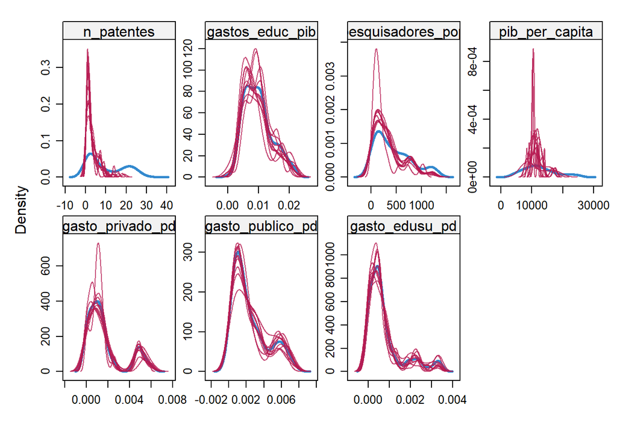

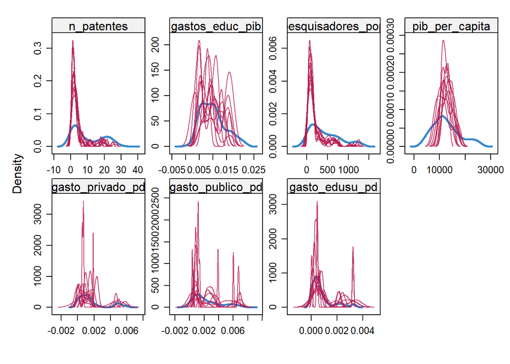

### Gerando painel imputado

Com base no exposto, o presente trabalho objetivou implementar quatro tipos de modelos - “Ordinary Least Squares”, “Fixed effects using Least squares dummy variable”, ” Fixed effects using within model”, “Random effects”.

# Resultados

## Painel de dados balanceado

### Comportamento da variável número de patentes entre os países

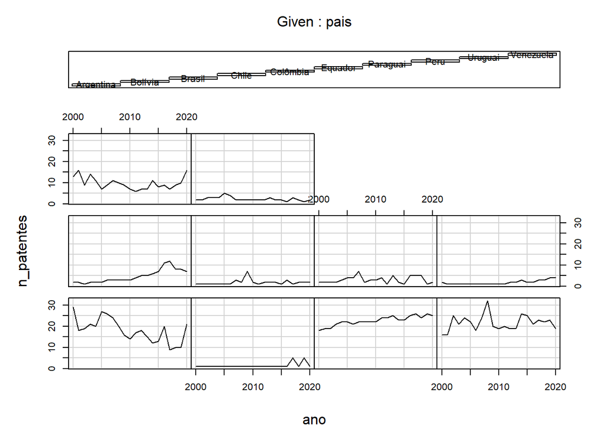

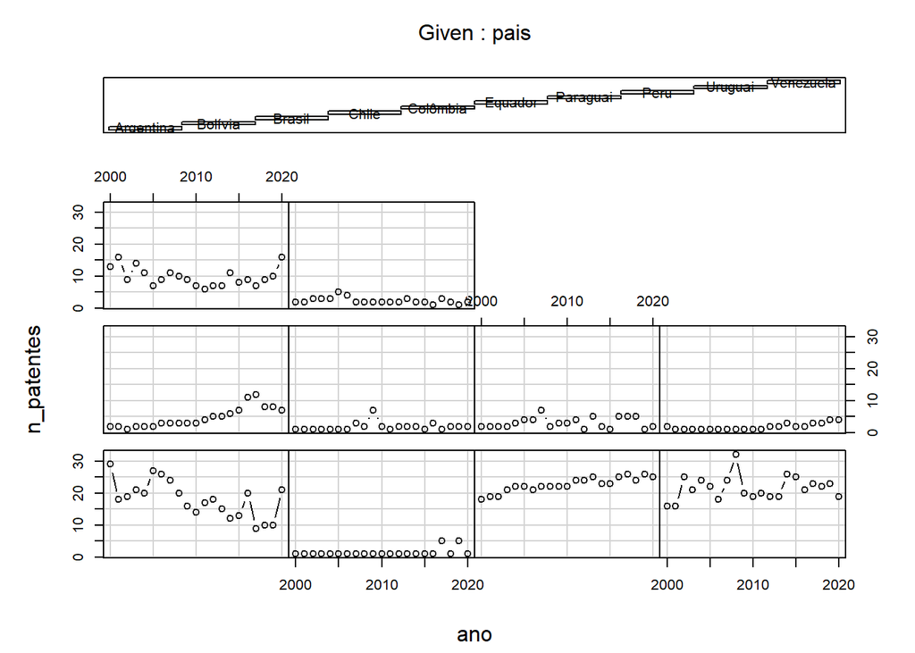

### Verificação da heterogeneidade das variáveis dependente entre os países

#### Número de patentes

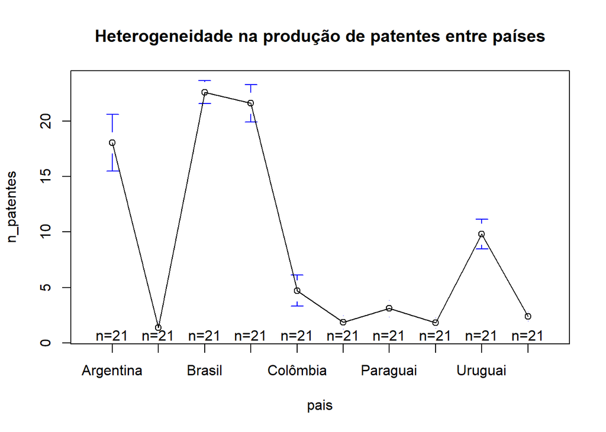

#### Número de publicações acadêmicas

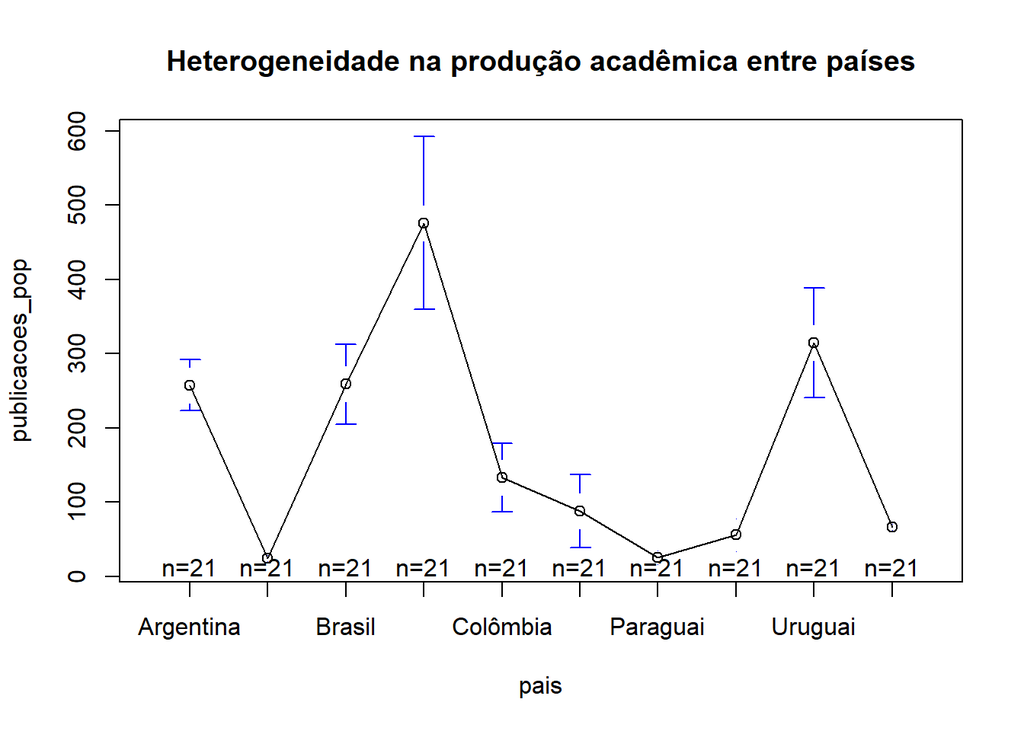

### Verificação da heterogeneidade das variáveis dependentes entre os anos

#### Número de patentes

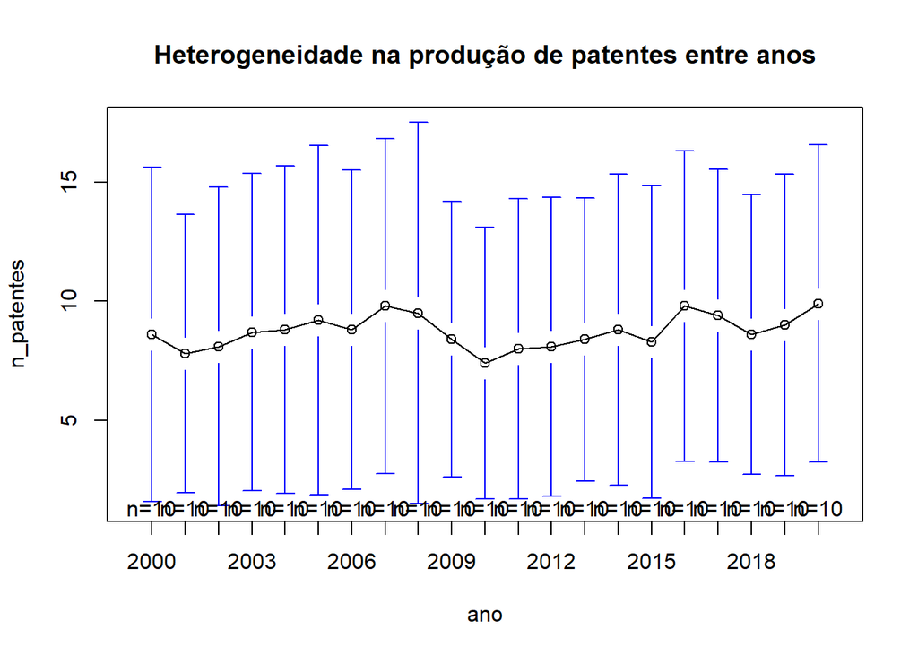

#### Número de publicações acadêmicas

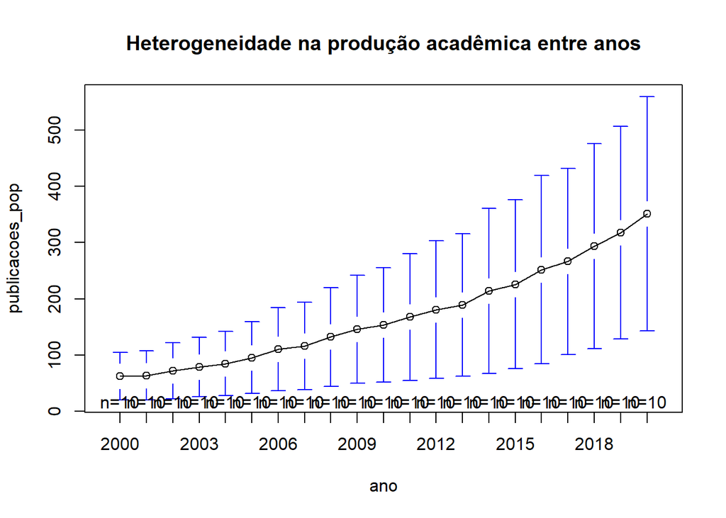

### Regressões

#### Regressão simples (OLS) com output de inovação - número de patentes

```r
reg_pb_ols_np <- lm(log(n_patentes) ~ log(pib_per_capita) + log(pesquisadores_pop) + gasto_privado_pd + gasto_publico_pd + gasto_edusu_pd + gastos_educ_pib, data = painel_imputado)

stargazer::stargazer(reg_pb_ols_np, type = "text")
```

```
##
## ==================================================
##                            Dependent variable:
##                        ---------------------------
##                              log(n_patentes)
## --------------------------------------------------
## log(pib_per_capita)             1.176***
##                                  (0.153)
##
## log(pesquisadores_pop)          0.408***
##                                  (0.077)
##
## gasto_privado_pd                89.548**
##                                 (35.660)
##
## gasto_publico_pd                 32.272
##                                 (33.550)
##
## gasto_edusu_pd                   117.266
##                                 (78.973)
##
## gastos_educ_pib                 -26.156**
##                                 (12.037)
##
## Constant                       -11.759***
##                                  (1.199)
##
## --------------------------------------------------
## Observations                       210
## R2                                0.614
## Adjusted R2                       0.603
## Residual Std. Error         0.747 (df = 203)
## F Statistic              53.836*** (df = 6; 203)
## ==================================================
## Note:                  *p<0.1; **p<0.05; ***p<0.01
```

#### Regressão simples (OLS) com output de inovação - produção acadêmica

```r
reg_pb_ols_pa <- lm(log(publicacoes_pop) ~ log(pib_per_capita) + log(pesquisadores_pop) + gasto_privado_pd + gasto_publico_pd + gasto_edusu_pd + gastos_educ_pib, data = painel_imputado)

stargazer::stargazer(reg_pb_ols_pa, type = "text")
```

```
##
## ==================================================
##                            Dependent variable:
##                        ---------------------------
##                           log(publicacoes_pop)
## --------------------------------------------------
## log(pib_per_capita)             1.766***
##                                  (0.113)
##
## log(pesquisadores_pop)          0.405***
##                                  (0.056)
##
## gasto_privado_pd                60.391**
##                                 (26.292)
##
## gasto_publico_pd                 28.147
##                                 (24.736)
##
## gasto_edusu_pd                   27.654
##                                 (58.226)
##
## gastos_educ_pib                 18.604**
##                                  (8.875)
##
## Constant                       -14.646***
##                                  (0.884)
##
## --------------------------------------------------
## Observations                       210
## R2                                0.811
## Adjusted R2                       0.805
## Residual Std. Error         0.551 (df = 203)
## F Statistic             144.947*** (df = 6; 203)
## ==================================================
## Note:                  *p<0.1; **p<0.05; ***p<0.01
```

#### Regressão controlando efeitos fixos dos países com variável dummy com output de inovação - número de patentes

```r
reg_pb_dfe_np <- lm(log(n_patentes) ~ log(pib_per_capita) + log(pesquisadores_pop) + gasto_privado_pd + gasto_publico_pd + gasto_edusu_pd + gastos_educ_pib + factor(pais) - 1, data = painel_imputado)

stargazer::stargazer(reg_pb_dfe_np, type = "text")
```

```
##
## ==================================================
##                            Dependent variable:
##                        ---------------------------
##                              log(n_patentes)
## --------------------------------------------------
## log(pib_per_capita)             0.607***
##                                  (0.122)
##
## log(pesquisadores_pop)          -0.117**
##                                  (0.055)
##
## gasto_privado_pd                48.629**
##                                 (22.138)
##
## gasto_publico_pd                 -9.032
##                                 (21.045)
##
## gasto_edusu_pd                   -40.075
##                                 (51.133)
##
## gastos_educ_pib                  -11.467
##                                  (9.432)
##
## factor(pais)Argentina            -2.134*
##                                  (1.100)
##
## factor(pais)Bolívia             -4.374***
##                                  (0.942)
##
## factor(pais)Brasil               -1.859*
##                                  (1.073)
##
## factor(pais)Chile                -2.075*
##                                  (1.103)
##
## factor(pais)Colômbia            -3.551***
##                                  (1.046)
##
## factor(pais)Equador             -4.387***
##                                  (1.016)
##
## factor(pais)Paraguai            -4.009***
##                                  (1.046)
##
## factor(pais)Peru                -4.447***
##                                  (1.042)
##
## factor(pais)Uruguai             -2.853***
##                                  (1.095)
##
## factor(pais)Venezuela           -4.240***
##                                  (1.062)
##
## --------------------------------------------------
## Observations                       210
## R2                                0.959
## Adjusted R2                       0.956
## Residual Std. Error         0.411 (df = 194)
## F Statistic             282.845*** (df = 16; 194)
## ==================================================
## Note:                  *p<0.1; **p<0.05; ***p<0.01
```

Nessa anáise a significância dos efeitos do pib, da força de trabalho em P&D e dos gastos privados possuem forte embasamento na literatura e foram verificados em outros trabalhos empíricos. Entretanto, o sinal negativo da força de trabalho potencialmente significa a existência de multicolienariedade.

#### Regressão controlando efeitos fixos dos países com variável dummy com output de inovação - produção acadêmica

```r
reg_pb_dfe_pa <- lm(log(publicacoes_pop) ~ log(pib_per_capita) + log(pesquisadores_pop) + gasto_privado_pd + gasto_publico_pd + gasto_edusu_pd + gastos_educ_pib + factor(pais) - 1, data = painel_imputado)

stargazer::stargazer(reg_pb_dfe_pa, type = "text")
```

```
##
## ==================================================
##                            Dependent variable:
##                        ---------------------------
##                           log(publicacoes_pop)
## --------------------------------------------------
## log(pib_per_capita)             2.003***
##                                  (0.102)
##
## log(pesquisadores_pop)           0.116**
##                                  (0.046)
##
## gasto_privado_pd                36.735**
##                                 (18.413)
##
## gasto_publico_pd                 33.424*
##                                 (17.505)
##
## gasto_edusu_pd                   -15.216
##                                 (42.531)
##
## gastos_educ_pib                  -9.565
##                                  (7.845)
##
## factor(pais)Argentina          -14.836***
##                                  (0.915)
##
## factor(pais)Bolívia            -14.573***
##                                  (0.783)
##
## factor(pais)Brasil             -14.502***
##                                  (0.892)
##
## factor(pais)Chile              -14.262***
##                                  (0.917)
##
## factor(pais)Colômbia           -14.637***
##                                  (0.870)
##
## factor(pais)Equador            -14.976***
##                                  (0.845)
##
## factor(pais)Paraguai           -16.091***
##                                  (0.870)
##
## factor(pais)Peru               -15.168***
##                                  (0.867)
##
## factor(pais)Uruguai            -14.619***
##                                  (0.911)
##
## factor(pais)Venezuela          -15.372***
##                                  (0.883)
##
## --------------------------------------------------
## Observations                       210
## R2                                0.995
## Adjusted R2                       0.995
## Residual Std. Error         0.342 (df = 194)
## F Statistic            2,428.299*** (df = 16; 194)
## ==================================================
## Note:                  *p<0.1; **p<0.05; ***p<0.01
```

#### Análise de componentes principais - variável dependente número de patentes

```r
modelo_patentes <- pcr(log(n_patentes) ~ log(pib_per_capita) + log(pesquisadores_pop) +
                       gasto_privado_pd + gasto_publico_pd + gasto_edusu_pd +
                       gastos_educ_pib + factor(pais) - 1,
                       data = painel_imputado,
                       scale = TRUE,
                       na.action = na.omit,
                       validation = "CV")
```

```
## Data:    X dimension: 210 16
##  Y dimension: 210 1
## Fit method: svdpc
## Number of components considered: 16
##
## VALIDATION: RMSEP
## Cross-validated using 10 random segments.
##        (Intercept)  1 comps  2 comps  3 comps  4 comps  5 comps  6 comps
## CV           1.188   0.8503   0.6675   0.6664   0.6653   0.6445   0.6313
## adjCV        1.188   0.8505   0.6666   0.6657   0.6651   0.6435   0.6291
##        7 comps  8 comps  9 comps  10 comps  11 comps  12 comps  13 comps
## CV      0.6233   0.6005   0.5461    0.5344    0.5400    0.5219    0.5227
## adjCV   0.6482   0.6374   0.5445    0.5328    0.5386    0.5203    0.5216
##        14 comps  15 comps  16 comps
## CV       0.4350    0.4231    0.4238
## adjCV    0.4324    0.4216    0.4217
##
## TRAINING: % variance explained
##                  1 comps  2 comps  3 comps  4 comps  5 comps  6 comps  7 comps
## X                  20.02    34.13    44.47    52.15    59.53    66.60    73.55
## log(n_patentes)    48.93    68.82    69.62    69.67    71.86    73.88    73.98
##                  8 comps  9 comps  10 comps  11 comps  12 comps  13 comps
## X                  80.49    87.43     91.16     94.11     96.44     98.02
## log(n_patentes)    74.93    81.05     81.78     81.81     82.91     83.24
##                  14 comps  15 comps  16 comps
## X                   99.17    100.00    100.00
## log(n_patentes)     88.17     88.86     88.86
```

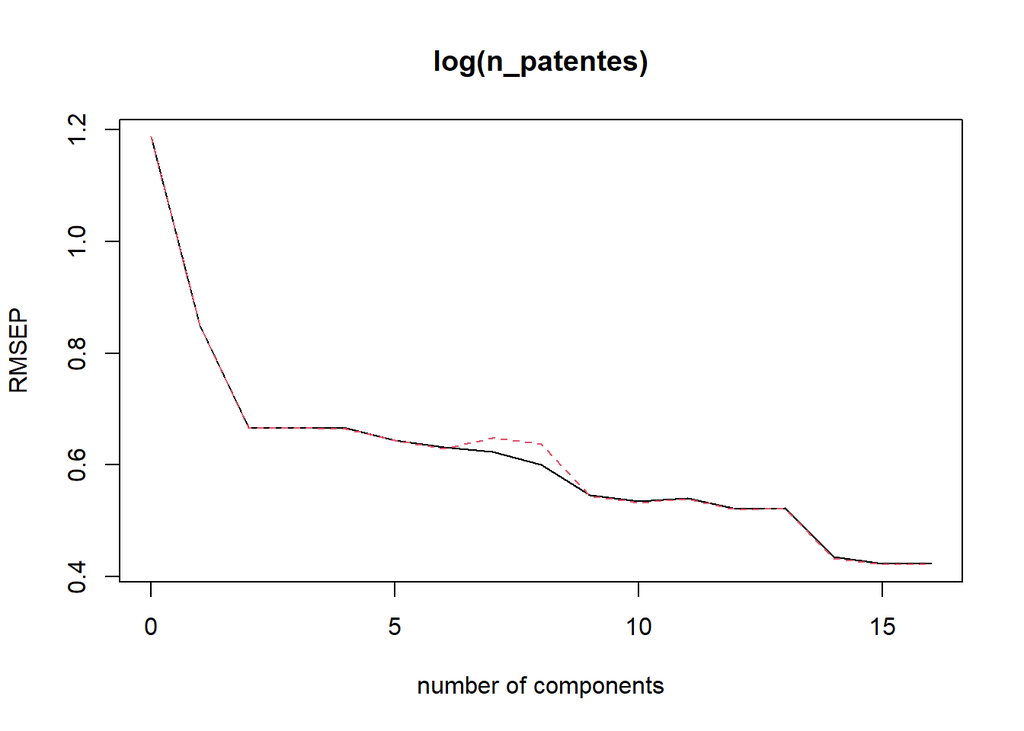

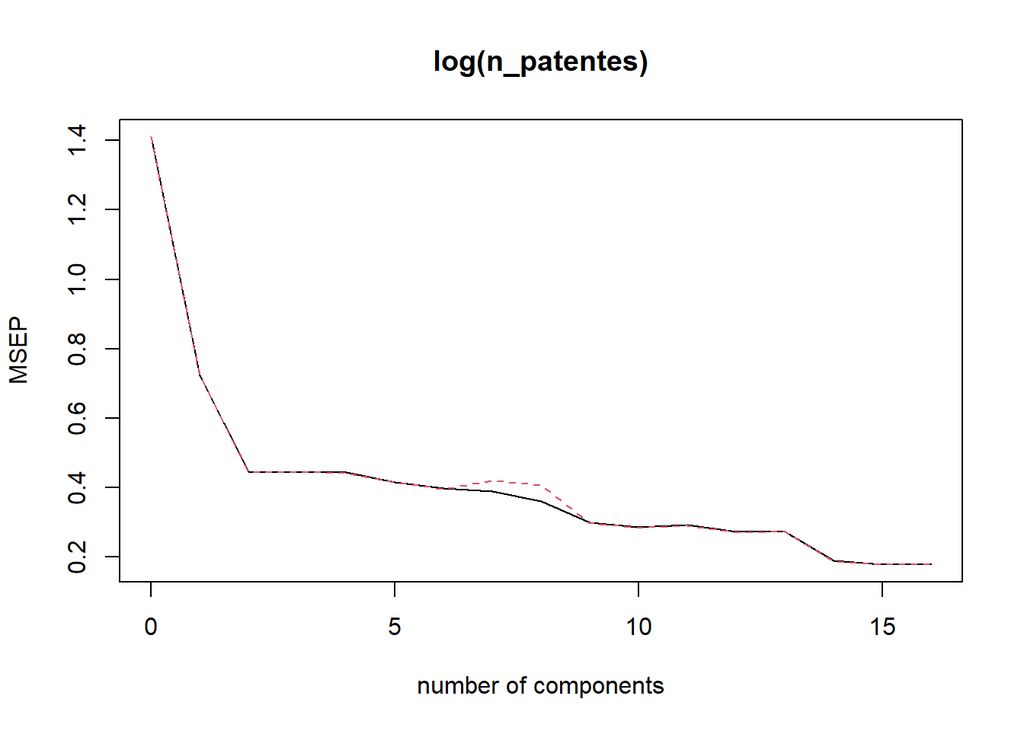

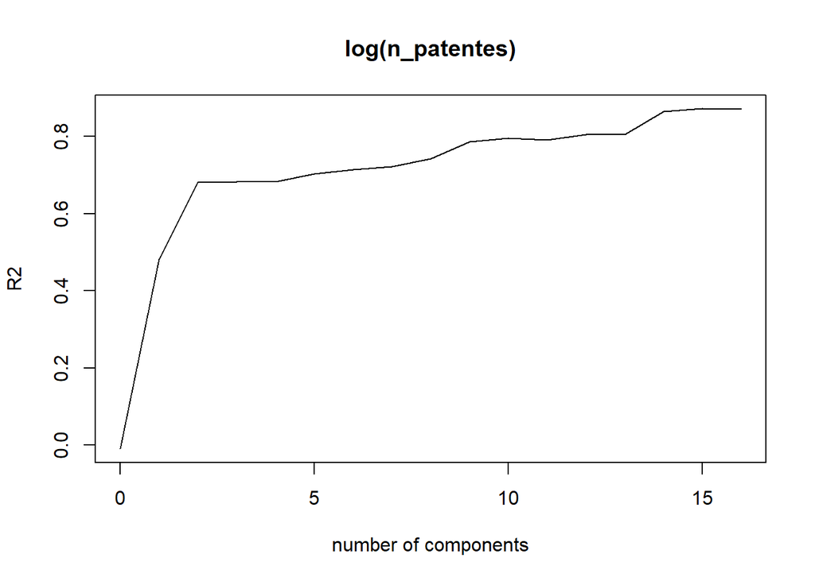

#### Análise de componentes principais - variável dependente produção acadêmica

```r
modelo_publicacoes <- pcr(log(publicacoes_pop) ~ log(pib_per_capita) + log(pesquisadores_pop) +
                       gasto_privado_pd + gasto_publico_pd + gasto_edusu_pd +
                       gastos_educ_pib + factor(pais) - 1,
                       data = painel_imputado,
                       scale = TRUE,
                       na.action = na.omit,
                       validation = "CV")
```

```
## Data:    X dimension: 210 16
##  Y dimension: 210 1
## Fit method: svdpc
## Number of components considered: 16
##
## VALIDATION: RMSEP
## Cross-validated using 10 random segments.
##        (Intercept)  1 comps  2 comps  3 comps  4 comps  5 comps  6 comps
## CV           1.251   0.9508   0.6728   0.5957   0.6026   0.5633   0.5581
## adjCV        1.251   0.9504   0.6723   0.5948   0.6027   0.5609   0.5574
##        7 comps  8 comps  9 comps  10 comps  11 comps  12 comps  13 comps
## CV      0.5488   0.4975   0.4766    0.4552    0.4530    0.4565    0.4614
## adjCV   0.4937   0.4709   0.4746    0.4534    0.4512    0.4544    0.4593
##        14 comps  15 comps  16 comps
## CV       0.4299    0.3703    0.3699
## adjCV    0.4270    0.3681    0.3660
##
## TRAINING: % variance explained
##                       1 comps  2 comps  3 comps  4 comps  5 comps  6 comps
## X                       20.02    34.13    44.47    52.15    59.53    66.60
## log(publicacoes_pop)    43.06    72.17    78.17    78.17    81.03    81.41
##                       7 comps  8 comps  9 comps  10 comps  11 comps  12 comps
## X                       73.55    80.49    87.43     91.16     94.11     96.44
## log(publicacoes_pop)    86.95    87.32    87.33     88.72     88.98     89.08
##                       13 comps  14 comps  15 comps  16 comps
## X                        98.02     99.17    100.00    100.00
## log(publicacoes_pop)     89.10     90.55     93.05     93.09
```

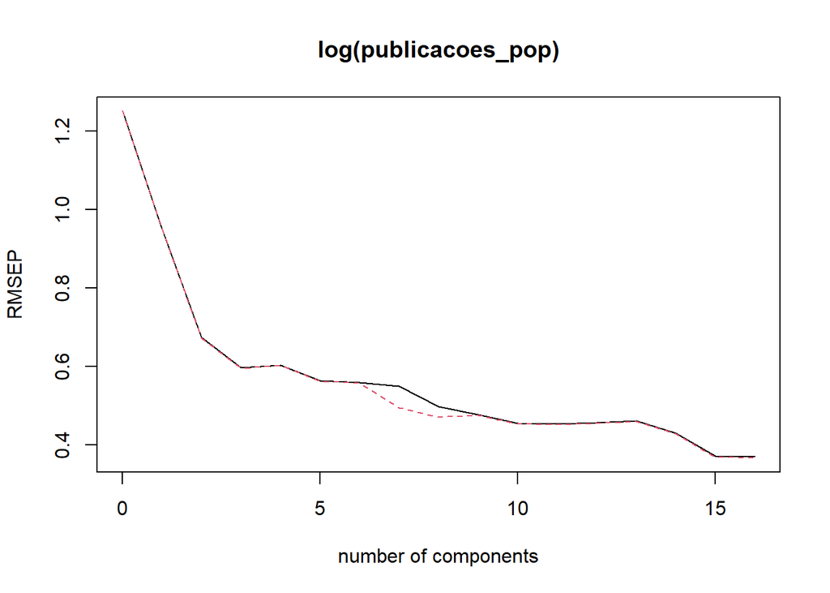

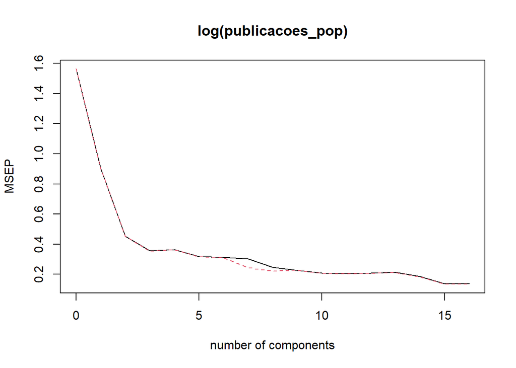

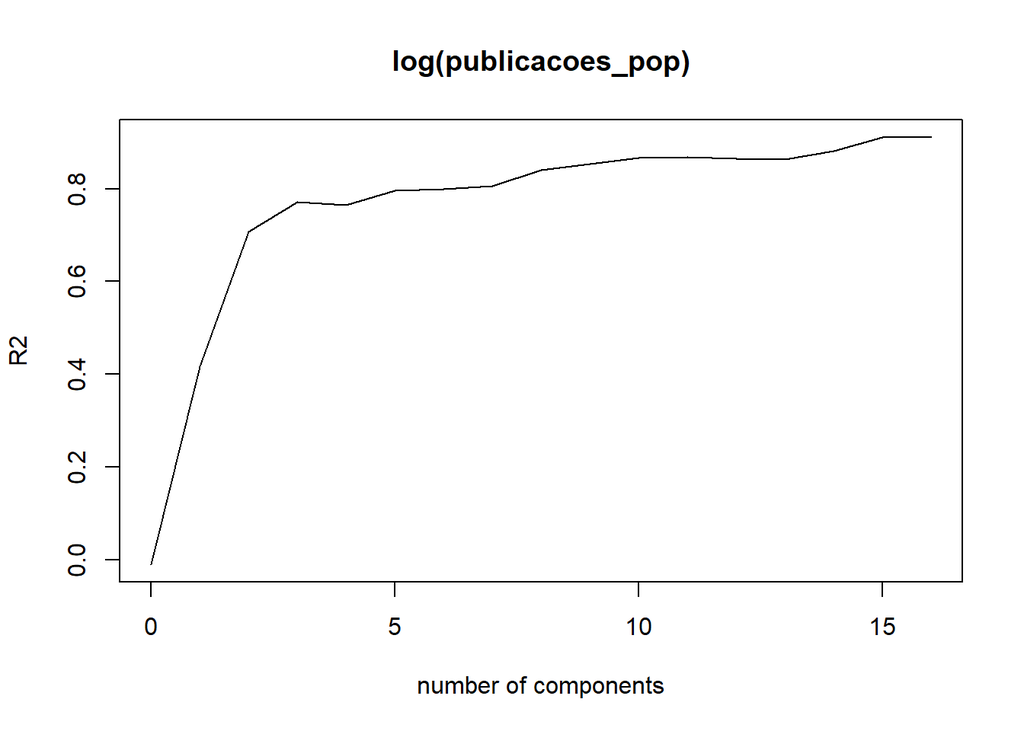

Ante todo o exposto, a relevância do fator países e de forma a controlar adequadamente a multicolineariedade, foi implementado modelo baseado em regressão de painel de dados de efeito fixos e aleatórios.

#### Gerando o painel balanceado

```r
painel_df_imputado <- pdata.frame(painel_imputado, index = c("pais", "ano"), drop.index = TRUE, row.names = TRUE)
head(painel_df_imputado)
```

```
##                n_patentes gastos_educ_pib pesquisadores_pop pib_per_capita
## Argentina-2000         29       0.0083064          716.6884      11544.409
## Argentina-2001         18       0.0082812          688.2427      11160.568
## Argentina-2002         19       0.0070274          692.1608       9991.382
## Argentina-2003         21       0.0057222          718.5463      10975.128
## Argentina-2004         20       0.0059985          766.0833      12163.783
## Argentina-2005         27       0.0062694          819.9057      13515.228
##                taxa_emprego gasto_privado_pd gasto_publico_pd gasto_edusu_pd
## Argentina-2000       52.960      0.001231899      0.003741511   0.0013235278
## Argentina-2001       50.990      0.001040863      0.003721568   0.0011847935
## Argentina-2002       48.436      0.001097585      0.003171297   0.0010437276
## Argentina-2003       51.697      0.001229809      0.003219153   0.0006033826
## Argentina-2004       53.566      0.001537552      0.003229446   0.0009786975
## Argentina-2005       54.430      0.001568726      0.003301279   0.0007056483
##                pop_milhao publicacoes_pop
## Argentina-2000   37.07077        150.5768
## Argentina-2001   37.48049        154.8005
## Argentina-2002   37.88503        164.5505
## Argentina-2003   38.27816        165.5774
## Argentina-2004   38.66880        171.5854
## Argentina-2005   39.07050        182.4394
```

##### Variável dependente - número de patentes

###### Regressão controlando efeitos fixos com modelo within

```r
reg_pb_fe_np <- plm(log(n_patentes) ~ log(pib_per_capita) + log(pesquisadores_pop) + gasto_privado_pd + gasto_publico_pd + gasto_edusu_pd + gastos_educ_pib, data = painel_df_imputado, model = "within")

stargazer::stargazer(reg_pb_fe_np, type = "text")
```

```
##
## ==================================================
##                            Dependent variable:
##                        ---------------------------
##                              log(n_patentes)
## --------------------------------------------------
## log(pib_per_capita)             0.607***
##                                  (0.122)
##
## log(pesquisadores_pop)          -0.117**
##                                  (0.055)
##
## gasto_privado_pd                48.629**
##                                 (22.138)
##
## gasto_publico_pd                 -9.032
##                                 (21.045)
##
## gasto_edusu_pd                   -40.075
##                                 (51.133)
##
## gastos_educ_pib                  -11.467
##                                  (9.432)
##
## --------------------------------------------------
## Observations                       210
## R2                                0.151
## Adjusted R2                       0.085
## F Statistic              5.736*** (df = 6; 194)
## ==================================================
## Note:                  *p<0.1; **p<0.05; ***p<0.01
```

```r
pFtest(reg_pb_fe_np, reg_pb_ols_np)
```

```
##
##  F test for individual effects
##
## data:  log(n_patentes) ~ log(pib_per_capita) + log(pesquisadores_pop) +  ...
## F = 53.09, df1 = 9, df2 = 194, p-value < 2.2e-16
## alternative hypothesis: significant effects
```

Com base no p-valor rejeitamos a hipótese nula. Isso significa que há efeitos individuais significativos no modelo, e, portanto, o modelo de efeitos fixos é preferível ao modelo agrupado (pooled) simples, que não leva em conta as diferenças individuais entre as unidades.

###### Regressão controlando efeitos aleatórios com modelo random

```r
reg_pb_re_np <- plm(log(n_patentes) ~  log(pib_per_capita) + log(pesquisadores_pop) + gasto_privado_pd + gasto_publico_pd + gasto_edusu_pd + gastos_educ_pib, data = painel_df_imputado, model = "random")


stargazer::stargazer(reg_pb_re_np, type = "text")
```

```
##
## ==================================================
##                            Dependent variable:
##                        ---------------------------
##                              log(n_patentes)
## --------------------------------------------------
## log(pib_per_capita)             0.684***
##                                  (0.125)
##
## log(pesquisadores_pop)           -0.075
##                                  (0.057)
##
## gasto_privado_pd                53.130**
##                                 (23.041)
##
## gasto_publico_pd                 -4.322
##                                 (21.902)
##
## gasto_edusu_pd                   -24.026
##                                 (53.022)
##
## gastos_educ_pib                 -16.025*
##                                  (9.670)
##
## Constant                        -4.323***
##                                  (1.081)
##
## --------------------------------------------------
## Observations                       210
## R2                                0.160
## Adjusted R2                       0.135
## F Statistic                     38.557***
## ==================================================
## Note:                  *p<0.1; **p<0.05; ***p<0.01
```

###### Teste de Hausman

```r
phtest(reg_pb_fe_np, reg_pb_re_np)
```

```
##
##  Hausman Test
##
## data:  log(n_patentes) ~ log(pib_per_capita) + log(pesquisadores_pop) +  ...
## chisq = 403.37, df = 6, p-value < 2.2e-16
## alternative hypothesis: one model is inconsistent
```

O resultado do teste indica a preferência pelo modelo de efeitos fixos.

##### Variável dependente - publicações por milhão de habitantes

###### Regressão controlando efeitos fixos com modelo within

```r
reg_pb_fe_pa <- plm(log(publicacoes_pop) ~ log(pib_per_capita) + log(pesquisadores_pop) + gasto_privado_pd + gasto_publico_pd + gasto_edusu_pd + gastos_educ_pib, data = painel_df_imputado, model = "within")

stargazer::stargazer(reg_pb_fe_pa, type = "text")
```

```
##
## ==================================================
##                            Dependent variable:
##                        ---------------------------
##                           log(publicacoes_pop)
## --------------------------------------------------
## log(pib_per_capita)             2.003***
##                                  (0.102)
##
## log(pesquisadores_pop)           0.116**
##                                  (0.046)
##
## gasto_privado_pd                36.735**
##                                 (18.413)
##
## gasto_publico_pd                 33.424*
##                                 (17.505)
##
## gasto_edusu_pd                   -15.216
##                                 (42.531)
##
## gastos_educ_pib                  -9.565
##                                  (7.845)
##
## --------------------------------------------------
## Observations                       210
## R2                                0.759
## Adjusted R2                       0.740
## F Statistic             101.739*** (df = 6; 194)
## ==================================================
## Note:                  *p<0.1; **p<0.05; ***p<0.01
```

O modelo apresenta efeitos consistentes com a literatura.

```r
pFtest(reg_pb_fe_pa, reg_pb_ols_pa)
```

```
##
##  F test for individual effects
##
## data:  log(publicacoes_pop) ~ log(pib_per_capita) + log(pesquisadores_pop) +  ...
## F = 37.098, df1 = 9, df2 = 194, p-value < 2.2e-16
## alternative hypothesis: significant effects
```

Com base no p-valor rejeitamos a hipótese nula. Isso significa que há efeitos individuais significativos no modelo, e, portanto, o modelo de efeitos fixos é preferível ao modelo agrupado (pooled) simples, que não leva em conta as diferenças individuais entre as unidades.

###### Regressão controlando efeitos aleatórios com modelo random

```r
reg_pb_re_pa <- plm(log(publicacoes_pop) ~  log(pib_per_capita) + log(pesquisadores_pop) + gasto_privado_pd + gasto_publico_pd + gasto_edusu_pd + gastos_educ_pib, data = painel_df_imputado, model = "random")


stargazer::stargazer(reg_pb_re_pa, type = "text")
```

```
##
## ==================================================
##                            Dependent variable:
##                        ---------------------------
##                           log(publicacoes_pop)
## --------------------------------------------------
## log(pib_per_capita)             2.000***
##                                  (0.100)
##
## log(pesquisadores_pop)          0.128***
##                                  (0.045)
##
## gasto_privado_pd                38.184**
##                                 (18.294)
##
## gasto_publico_pd                34.395**
##                                 (17.390)
##
## gasto_edusu_pd                   -10.887
##                                 (42.136)
##
## gastos_educ_pib                  -9.050
##                                  (7.705)
##
## Constant                       -14.953***
##                                  (0.867)
##
## --------------------------------------------------
## Observations                       210
## R2                                0.759
## Adjusted R2                       0.752
## F Statistic                    640.796***
## ==================================================
## Note:                  *p<0.1; **p<0.05; ***p<0.01
```

###### Teste de Hausman

```r
phtest(reg_pb_fe_pa, reg_pb_re_pa)
```

```
##
##  Hausman Test
##
## data:  log(publicacoes_pop) ~ log(pib_per_capita) + log(pesquisadores_pop) +  ...
## chisq = 3.6501, df = 6, p-value = 0.7239
## alternative hypothesis: one model is inconsistent
```

## Painel de dados não balanceado

### Comportamento da variável número de patentes entre os países

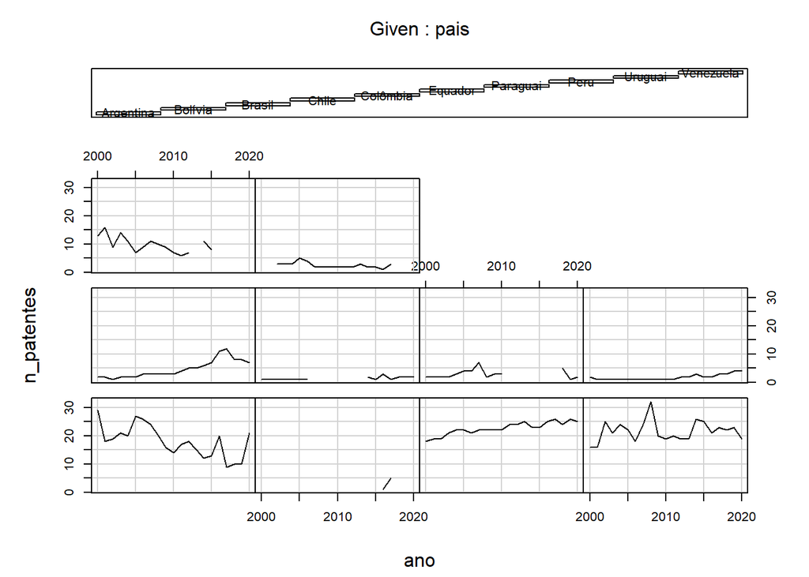

```
##
##  Missing rows: 43, 44, 45, 46, 47, 48, 49, 50, 51, 52, 53, 54, 55, 56, 58, 61, 62, 113, 114, 115, 116, 117, 118, 119, 138, 139, 140, 141, 142, 143, 144, 182, 185, 187, 188, 189, 191, 208, 209, 210
```

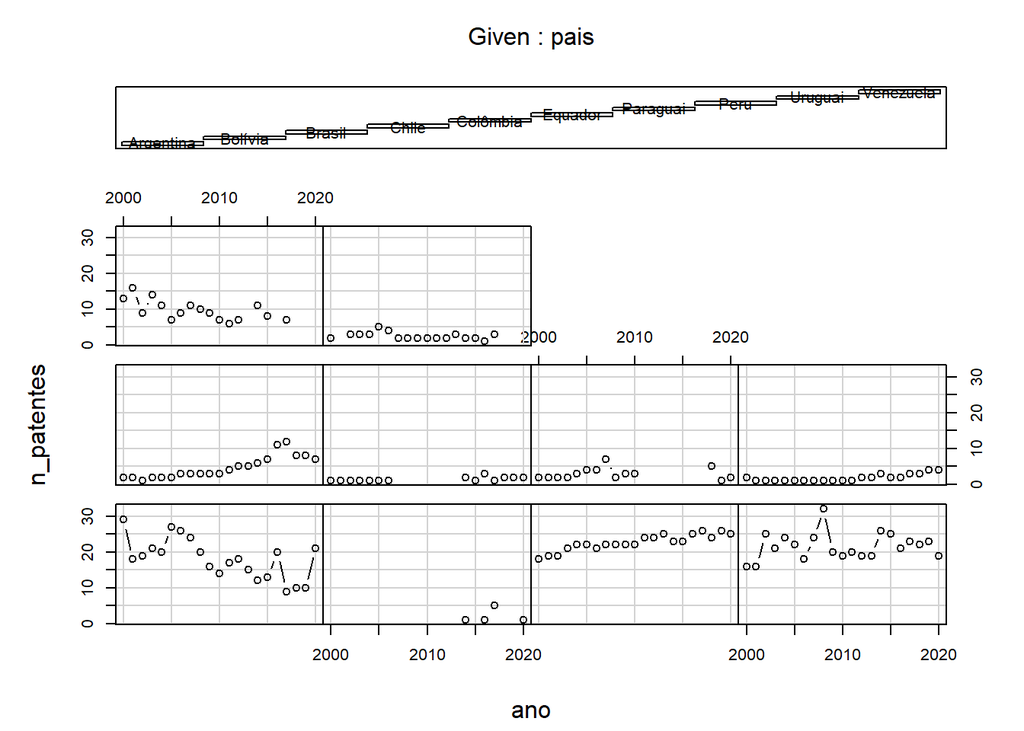

```
##
##  Missing rows: 43, 44, 45, 46, 47, 48, 49, 50, 51, 52, 53, 54, 55, 56, 58, 61, 62, 113, 114, 115, 116, 117, 118, 119, 138, 139, 140, 141, 142, 143, 144, 182, 185, 187, 188, 189, 191, 208, 209, 210
```

### Verificação da heterogeneidade das variáveis dependente entre os países

#### Número de patentes

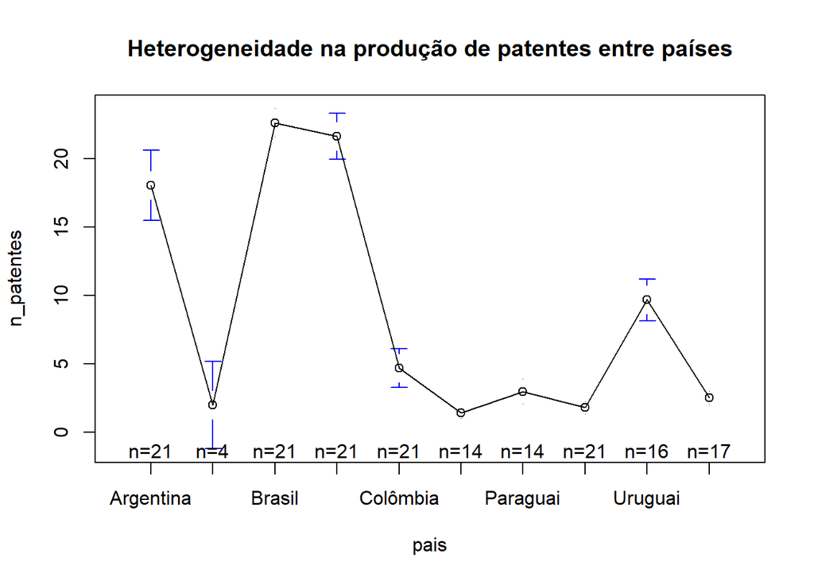

#### Número de publicações acadêmicas

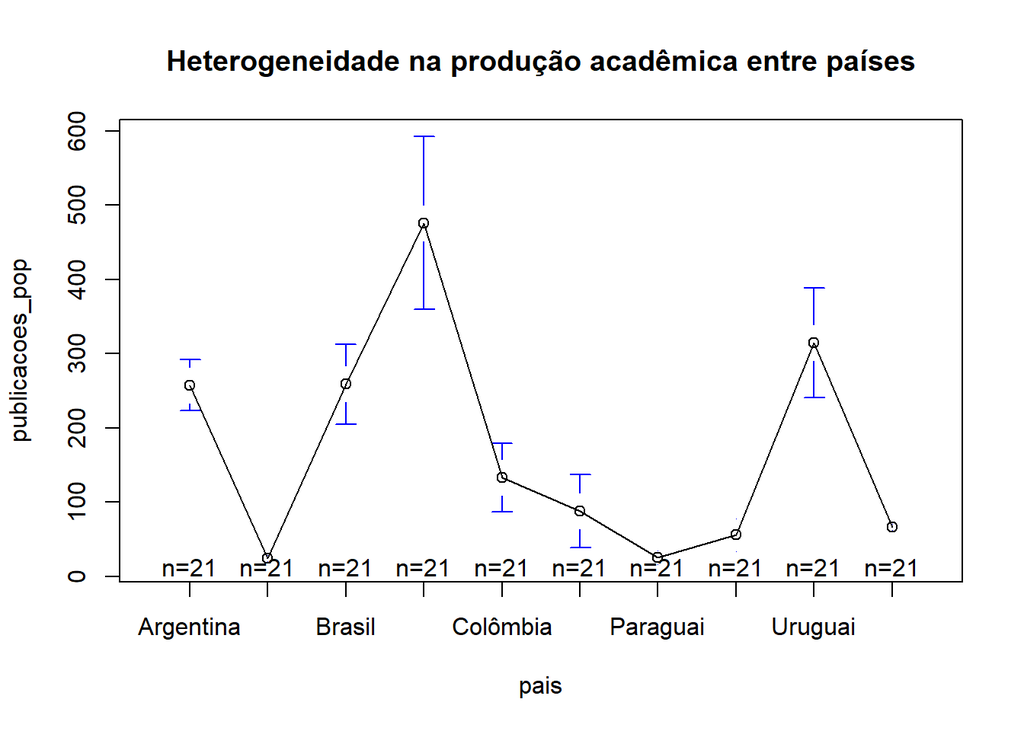

### Verificação da heterogeneidade das variáveis dependentes entre os anos

#### Número de patentes

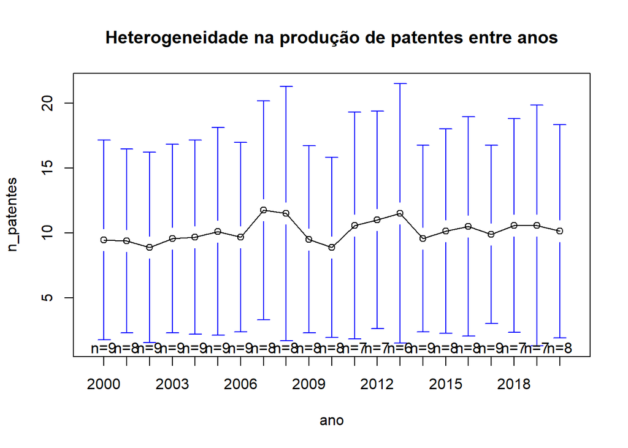

#### Número de publicações acadêmicas

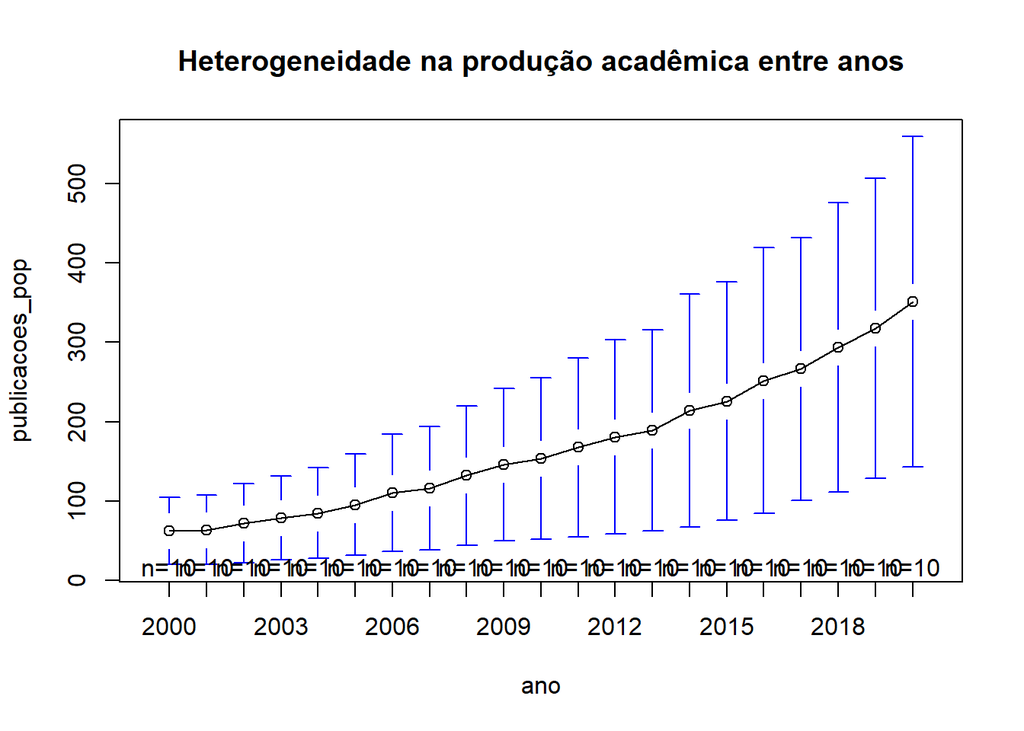

### Regressões

#### Regressão simples (OLS) com output de inovação - número de patentes

```r
reg_pub_ols_np <- lm(log(n_patentes) ~ log(pib_per_capita) + log(pesquisadores_pop) + gasto_privado_pd + gasto_publico_pd + gasto_edusu_pd + gastos_educ_pib, data = painel_inovacao)

stargazer::stargazer(reg_pub_ols_np, type = "text")
```

```
##
## ==================================================
##                            Dependent variable:
##                        ---------------------------
##                              log(n_patentes)
## --------------------------------------------------
## log(pib_per_capita)             1.373***
##                                  (0.366)
##
## log(pesquisadores_pop)            0.134
##                                  (0.176)
##
## gasto_privado_pd                 93.684
##                                 (98.516)
##
## gasto_publico_pd                 28.795
##                                 (145.646)
##
## gasto_edusu_pd                   257.050
##                                 (272.085)
##
## gastos_educ_pib                -110.285***
##                                 (30.593)
##
## Constant                       -10.830***
##                                  (2.688)
##
## --------------------------------------------------
## Observations                       57
## R2                                0.623
## Adjusted R2                       0.578
## Residual Std. Error          0.478 (df = 50)
## F Statistic              13.779*** (df = 6; 50)
## ==================================================
## Note:                  *p<0.1; **p<0.05; ***p<0.01
```

#### Regressão simples (OLS) com output de inovação - produção acadêmica

```r
reg_pub_ols_pa <- lm(log(publicacoes_pop) ~ log(pib_per_capita) + log(pesquisadores_pop) + gasto_privado_pd + gasto_publico_pd + gasto_edusu_pd + gastos_educ_pib, data = painel_inovacao)

stargazer::stargazer(reg_pub_ols_pa, type = "text")
```

```
##
## ==================================================
##                            Dependent variable:
##                        ---------------------------
##                           log(publicacoes_pop)
## --------------------------------------------------
## log(pib_per_capita)             2.567***
##                                  (0.249)
##
## log(pesquisadores_pop)            0.136
##                                  (0.133)
##
## gasto_privado_pd                194.318**
##                                 (78.791)
##
## gasto_publico_pd                -135.659
##                                 (110.354)
##
## gasto_edusu_pd                   311.361
##                                 (237.166)
##
## gastos_educ_pib                  12.586
##                                 (19.834)
##
## Constant                       -20.630***
##                                  (1.864)
##
## --------------------------------------------------
## Observations                       71
## R2                                0.860
## Adjusted R2                       0.846
## Residual Std. Error          0.479 (df = 64)
## F Statistic              65.270*** (df = 6; 64)
## ==================================================
## Note:                  *p<0.1; **p<0.05; ***p<0.01
```

#### Regressão controlando efeitos fixos dos países com variável dummy com output de inovação - número de patentes

```r
reg_pub_dfe_np <- lm(log(n_patentes) ~ log(pib_per_capita) + log(pesquisadores_pop) + gasto_privado_pd + gasto_publico_pd + gasto_edusu_pd + gastos_educ_pib + factor(pais) - 1, data = painel_inovacao)

stargazer::stargazer(reg_pub_dfe_np, type = "text")
```

```
##
## ==================================================
##                            Dependent variable:
##                        ---------------------------
##                              log(n_patentes)
## --------------------------------------------------
## log(pib_per_capita)             -1.600***
##                                  (0.339)
##
## log(pesquisadores_pop)          1.421***
##                                  (0.303)
##
## gasto_privado_pd                212.502*
##                                 (124.209)
##
## gasto_publico_pd                 22.584
##                                 (73.399)
##
## gasto_edusu_pd                  -233.824
##                                 (148.600)
##
## gastos_educ_pib                  -14.825
##                                 (22.104)
##
## factor(pais)Argentina           8.646***
##                                  (1.941)
##
## factor(pais)Brasil              8.557***
##                                  (1.999)
##
## factor(pais)Chile               10.481***
##                                  (2.075)
##
## factor(pais)Colômbia            11.155***
##                                  (2.228)
##
## factor(pais)Equador             7.647***
##                                  (1.833)
##
## factor(pais)Paraguai            8.705***
##                                  (2.016)
##
## factor(pais)Uruguai             8.581***
##                                  (2.011)
##
## --------------------------------------------------
## Observations                       57
## R2                                0.996
## Adjusted R2                       0.995
## Residual Std. Error          0.197 (df = 44)
## F Statistic             861.086*** (df = 13; 44)
## ==================================================
## Note:                  *p<0.1; **p<0.05; ***p<0.01
```

Nessa anáise a significância dos efeitos do pib e da força de trabalho em P&D possuem forte embasamento na literatura e foram verificados em outros trabalhos empíricos. Entretanto, o sinal negativo do pib per capita se demonstra incoerente com a literatura.

#### Regressão controlando efeitos fixos dos países com variável dummy com output de inovação - produção acadêmica

```r
reg_pub_dfe_pa <- lm(log(publicacoes_pop) ~ log(pib_per_capita) + log(pesquisadores_pop) + gasto_privado_pd + gasto_publico_pd + gasto_edusu_pd + gastos_educ_pib + factor(pais) - 1, data = painel_inovacao)

stargazer::stargazer(reg_pub_dfe_pa, type = "text")
```

```
##
## ==================================================
##                            Dependent variable:
##                        ---------------------------
##                           log(publicacoes_pop)
## --------------------------------------------------
## log(pib_per_capita)             1.447***
##                                  (0.179)
##
## log(pesquisadores_pop)            0.146
##                                  (0.117)
##
## gasto_privado_pd                 30.494
##                                 (93.311)
##
## gasto_publico_pd                 45.475
##                                 (50.516)
##
## gasto_edusu_pd                   174.977
##                                 (106.969)
##
## gastos_educ_pib                  13.179
##                                 (14.590)
##
## factor(pais)Argentina          -10.021***
##                                  (1.309)
##
## factor(pais)Bolívia            -10.174***
##                                  (1.083)
##
## factor(pais)Brasil             -10.191***
##                                  (1.311)
##
## factor(pais)Chile               -9.277***
##                                  (1.352)
##
## factor(pais)Colômbia            -9.359***
##                                  (1.357)
##
## factor(pais)Equador            -10.887***
##                                  (1.218)
##
## factor(pais)Paraguai           -11.407***
##                                  (1.296)
##
## factor(pais)Uruguai             -9.669***
##                                  (1.342)
##
## --------------------------------------------------
## Observations                       71
## R2                                0.999
## Adjusted R2                       0.999
## Residual Std. Error          0.162 (df = 57)
## F Statistic            5,536.232*** (df = 14; 57)
## ==================================================
## Note:                  *p<0.1; **p<0.05; ***p<0.01
```

O modelo apontado possui forte adequação a parte da literatura que apresenta que grande parte do efeito sobre a variável dependente provém das variações no PIB, além do R2 Ajustado de 99.9% e estatística F significativa. Nessa linha, as variações entre os países se apresentam como relevantes variáveis com impacto nos resultados da inovação.

#### Gerando o painel não balanceado

A literatura de análise de dados em painel apresenta que os paineis não balanceados, com valores faltantes, são analisáveis através do uso do ferramental adequado.

```r
painel_df_inovacao <- pdata.frame(painel_inovacao, index = c("pais", "ano"), drop.index = TRUE, row.names = TRUE)
head(painel_df_inovacao)
```

```
##                n_patentes gastos_educ_pib pesquisadores_pop pib_per_capita
## Argentina-2000         29       0.0083064          716.6884      11544.409
## Argentina-2001         18       0.0082812          688.2427      11160.568
## Argentina-2002         19       0.0070274          692.1608       9991.382
## Argentina-2003         21       0.0057222          718.5463      10975.128
## Argentina-2004         20       0.0059985          766.0833      12163.783
## Argentina-2005         27       0.0062694          819.9057      13515.228
##                taxa_emprego gasto_privado_pd gasto_publico_pd gasto_edusu_pd
## Argentina-2000       52.960      0.001231899      0.003741511   0.0013235278
## Argentina-2001       50.990      0.001040863      0.003721568   0.0011847935
## Argentina-2002       48.436      0.001097585      0.003171297   0.0010437276
## Argentina-2003       51.697      0.001229809      0.003219153   0.0006033826
## Argentina-2004       53.566      0.001537552      0.003229446   0.0009786975
## Argentina-2005       54.430      0.001568726      0.003301279   0.0007056483
##                pop_milhao publicacoes_pop
## Argentina-2000   37.07077        150.5768
## Argentina-2001   37.48049        154.8005
## Argentina-2002   37.88503        164.5505
## Argentina-2003   38.27816        165.5774
## Argentina-2004   38.66880        171.5854
## Argentina-2005   39.07050        182.4394
```

##### Variável dependente - número de patentes

###### Regressão controlando efeitos fixos com modelo within

```r
reg_pub_fe_np <- plm(log(n_patentes) ~ log(pib_per_capita) + log(pesquisadores_pop) + gasto_privado_pd + gasto_publico_pd + gasto_edusu_pd + gastos_educ_pib, data = painel_df_inovacao, model = "within")

stargazer::stargazer(reg_pub_fe_np, type = "text")
```

```
##
## ==================================================
##                            Dependent variable:
##                        ---------------------------
##                              log(n_patentes)
## --------------------------------------------------
## log(pib_per_capita)             -1.600***
##                                  (0.339)
##
## log(pesquisadores_pop)          1.421***
##                                  (0.303)
##
## gasto_privado_pd                212.502*
##                                 (124.209)
##
## gasto_publico_pd                 22.584
##                                 (73.399)
##
## gasto_edusu_pd                  -233.824
##                                 (148.600)
##
## gastos_educ_pib                  -14.825
##                                 (22.104)
##
## --------------------------------------------------
## Observations                       57
## R2                                0.482
## Adjusted R2                       0.340
## F Statistic               6.817*** (df = 6; 44)
## ==================================================
## Note:                  *p<0.1; **p<0.05; ***p<0.01
```

```r
pFtest(reg_pb_fe_np, reg_pb_ols_np)
```

[output not shown]

Com base no p-valor rejeitamos a hipótese nula. Isso significa que há efeitos individuais significativos no modelo, e, portanto, o modelo de efeitos fixos é preferível ao modelo agrupado (pooled) simples, que não leva em conta as diferenças individuais entre as unidades.

###### Regressão controlando efeitos aleatórios com modelo random

```r
reg_pub_re_np <- plm(log(n_patentes) ~  log(pib_per_capita) + log(pesquisadores_pop) + gasto_privado_pd + gasto_publico_pd + gasto_edusu_pd, data = painel_df_inovacao, model = "random")


stargazer::stargazer(reg_pub_re_np, type = "text")
```

```
##
## ==================================================
##                            Dependent variable:
##                        ---------------------------
##                              log(n_patentes)
## --------------------------------------------------
## log(pib_per_capita)             -0.834***
##                                  (0.244)
##
## log(pesquisadores_pop)          0.640***
##                                  (0.198)
##
## gasto_privado_pd                236.918**
##                                 (98.482)
##
## gasto_publico_pd                 18.954
##                                 (75.637)
##
## gasto_edusu_pd                   -63.092
##                                 (155.429)
##
## Constant                        6.025***
##                                  (1.658)
##
## --------------------------------------------------
## Observations                       65
## R2                                0.247
## Adjusted R2                       0.183
## F Statistic                     28.869***
## ==================================================
## Note:                  *p<0.1; **p<0.05; ***p<0.01
```

###### Teste de Hausman

```r
phtest(reg_pub_fe_np, reg_pub_re_np)
```

```
##
##  Hausman Test
##
## data:  log(n_patentes) ~ log(pib_per_capita) + log(pesquisadores_pop) +  ...
## chisq = 10.745, df = 5, p-value = 0.05668
## alternative hypothesis: one model is inconsistent
```

##### Variável dependente - publicações por milhão de habitantes

###### Regressão controlando efeitos fixos com modelo within

```r
reg_pub_fe_pa <- plm(log(publicacoes_pop) ~ log(pib_per_capita) + log(pesquisadores_pop) + gasto_privado_pd + gasto_publico_pd + gasto_edusu_pd + gastos_educ_pib, data = painel_df_inovacao, model = "within")

stargazer::stargazer(reg_pub_fe_pa, type = "text")
```

```
##
## ==================================================
##                            Dependent variable:
##                        ---------------------------
##                           log(publicacoes_pop)
## --------------------------------------------------
## log(pib_per_capita)             1.447***
##                                  (0.179)
##
## log(pesquisadores_pop)            0.146
##                                  (0.117)
##
## gasto_privado_pd                 30.494
##                                 (93.311)
##
## gasto_publico_pd                 45.475
##                                 (50.516)
##
## gasto_edusu_pd                   174.977
##                                 (106.969)
##
## gastos_educ_pib                  13.179
##                                 (14.590)
##
## --------------------------------------------------
## Observations                       71
## R2                                0.860
## Adjusted R2                       0.828
## F Statistic              58.445*** (df = 6; 57)
## ==================================================
## Note:                  *p<0.1; **p<0.05; ***p<0.01
```

O modelo apresenta efeitos consistentes com a literatura.

```r
pFtest(reg_pub_fe_pa, reg_pub_ols_pa)
```

```
##
##  F test for individual effects
##
## data:  log(publicacoes_pop) ~ log(pib_per_capita) + log(pesquisadores_pop) +  ...
## F = 72.089, df1 = 7, df2 = 57, p-value < 2.2e-16
## alternative hypothesis: significant effects
```

Com base no p-valor rejeitamos a hipótese nula. Isso significa que há efeitos individuais significativos no modelo, e, portanto, o modelo de efeitos fixos é preferível ao modelo agrupado (pooled) simples, que não leva em conta as diferenças individuais entre as unidades.

###### Regressão controlando efeitos aleatórios com modelo random

```r
reg_pub_re_pa <- plm(log(publicacoes_pop) ~  log(pib_per_capita) + log(pesquisadores_pop) + gasto_privado_pd + gasto_publico_pd + gasto_edusu_pd + gastos_educ_pib, data = painel_df_inovacao, model = "random")


stargazer::stargazer(reg_pub_re_pa, type = "text")
```

```
##
## ==================================================
##                            Dependent variable:
##                        ---------------------------
##                           log(publicacoes_pop)
## --------------------------------------------------
## log(pib_per_capita)             1.478***
##                                  (0.170)
##
## log(pesquisadores_pop)            0.146
##                                  (0.111)
##
## gasto_privado_pd                 50.384
##                                 (86.622)
##
## gasto_publico_pd                 43.528
##                                 (49.216)
##
## gasto_edusu_pd                   166.762
##                                 (104.147)
##
## gastos_educ_pib                  11.809
##                                 (13.840)
##
## Constant                       -10.414***
##                                  (1.240)
##
## --------------------------------------------------
## Observations                       71
## R2                                0.854
## Adjusted R2                       0.840
## F Statistic                    376.757***
## ==================================================
## Note:                  *p<0.1; **p<0.05; ***p<0.01
```

###### Teste de Hausman

```r
phtest(reg_pub_fe_pa, reg_pub_re_pa)
```

```
##
##  Hausman Test
##
## data:  log(publicacoes_pop) ~ log(pib_per_capita) + log(pesquisadores_pop) +  ...
## chisq = 1.0166, df = 6, p-value = 0.985
## alternative hypothesis: one model is inconsistent
```

### Comparação dos modelos com base no painel balanceado - variável dependente número de patentes

```
##
## Comparação de Modelos Implementados - Painel Balanceado
## =============================================================================================================================
##                                                                           Dependent variable:
##                                            ----------------------------------------------------------------------------------
##                                                                            Número de Patentes
##                                                                   OLS                                     panel
##                                                                                                           linear
##                                                      OLS                    OLS FED                    FE              RE
##                                                      (1)                      (2)                     (3)              (4)
## -----------------------------------------------------------------------------------------------------------------------------
## Log PIB per Capita                                1.176***                 0.607***                 0.607***        0.684***
##                                                    (0.153)                  (0.122)                 (0.122)          (0.125)
##
## Log Pesquisadores por Milhão de Habitantes        0.408***                 -0.117**                 -0.117**         -0.075
##                                                    (0.077)                  (0.055)                 (0.055)          (0.057)
##
## Gasto Privado em P&D                              89.548**                 48.629**                 48.629**        53.130**
##                                                   (35.660)                 (22.138)                 (22.138)        (23.041)
##
## Gasto Público em P&D                               32.272                   -9.032                   -9.032          -4.322
##                                                   (33.550)                 (21.045)                 (21.045)        (21.902)
##
## Gasto do Ensino Superior em P&D                    117.266                  -40.075                 -40.075          -24.026
##                                                   (78.973)                 (51.133)                 (51.133)        (53.022)
##
## Gastos em Educação                                -26.156**                 -11.467                 -11.467         -16.025*
##                                                   (12.037)                  (9.432)                 (9.432)          (9.670)
##
## factor(pais)Argentina                                                       -2.134*
##                                                                             (1.100)
##
## factor(pais)Bolívia                                                        -4.374***
##                                                                             (0.942)
##
## factor(pais)Brasil                                                          -1.859*
##                                                                             (1.073)
##
## factor(pais)Chile                                                           -2.075*
##                                                                             (1.103)
```

[output cut: 14 more lines]

```
##                                                                             (1.095)
##
## factor(pais)Venezuela                                                      -4.240***
##                                                                             (1.062)
##
## Constant                                         -11.759***                                                         -4.323***
##                                                    (1.199)                                                           (1.081)
##
## -----------------------------------------------------------------------------------------------------------------------------
## Observations                                         210                      210                     210              210
## R2                                                  0.614                    0.959                   0.151            0.160
## Adjusted R2                                         0.603                    0.956                   0.085            0.135
## F Statistic                                53.836*** (df = 6; 203) 282.845*** (df = 16; 194) 5.736*** (df = 6; 194) 38.557***
## =============================================================================================================================
## Note:                                                                                             *p<0.1; **p<0.05; ***p<0.01
```

### Comparação dos modelos com base no painel balanceado - variável publicações por milhão de habitantes

```
##
## Comparação de Modelos Implementados - Painel Balanceado
## ===================================================================================================================================
##                                                                              Dependent variable:
##                                            ----------------------------------------------------------------------------------------
##                                                                      Publicações por Milhão de Habitantes
##                                                                    OLS                                         panel
##                                                                                                               linear
##                                                      OLS                      OLS FED                      FE                RE
##                                                      (1)                        (2)                       (3)               (4)
## -----------------------------------------------------------------------------------------------------------------------------------
## Log PIB per Capita                                 1.766***                  2.003***                   2.003***          2.000***
##                                                    (0.113)                    (0.102)                   (0.102)           (0.100)
##
## Log Pesquisadores por Milhão de Habitantes         0.405***                   0.116**                   0.116**           0.128***
##                                                    (0.056)                    (0.046)                   (0.046)           (0.045)
##
## Gasto Privado em P&D                               60.391**                  36.735**                   36.735**          38.184**
##                                                    (26.292)                  (18.413)                   (18.413)          (18.294)
##
## Gasto Público em P&D                                28.147                    33.424*                   33.424*           34.395**
##                                                    (24.736)                  (17.505)                   (17.505)          (17.390)
##
## Gasto do Ensino Superior em P&D                     27.654                    -15.216                   -15.216           -10.887
##                                                    (58.226)                  (42.531)                   (42.531)          (42.136)
##
## Gastos em Educação                                 18.604**                   -9.565                     -9.565            -9.050
##                                                    (8.875)                    (7.845)                   (7.845)           (7.705)
##
## factor(pais)Argentina                                                       -14.836***
##                                                                               (0.915)
##
## factor(pais)Bolívia                                                         -14.573***
##                                                                               (0.783)
##
## factor(pais)Brasil                                                          -14.502***
##                                                                               (0.892)
##
## factor(pais)Chile                                                           -14.262***
##                                                                               (0.917)
```

[output cut: 14 more lines]

```
##                                                                               (0.911)
##
## factor(pais)Venezuela                                                       -15.372***
##                                                                               (0.883)
##
## Constant                                          -14.646***                                                             -14.953***
##                                                    (0.884)                                                                (0.867)
##
## -----------------------------------------------------------------------------------------------------------------------------------
## Observations                                         210                        210                       210               210
## R2                                                  0.811                      0.995                     0.759             0.759
## Adjusted R2                                         0.805                      0.995                     0.740             0.752
## F Statistic                                144.947*** (df = 6; 203) 2,428.299*** (df = 16; 194) 101.739*** (df = 6; 194) 640.796***
## ===================================================================================================================================
## Note:                                                                                                   *p<0.1; **p<0.05; ***p<0.01
```

### Comparação dos modelos com base no painel não balanceado - variável dependente número de patentes

[output not shown]

### Comparação dos modelos com base no painel não balanceado - variável publicações por milhão de habitantes

[output not shown]

[output cut: 8 more lines]

```
##                                                                            (1.296)
##
## factor(pais)Uruguai                                                       -9.669***
##                                                                            (1.342)
##
## Constant                                         -20.630***                                                         -10.414***
##                                                   (1.864)                                                            (1.240)
##
## ------------------------------------------------------------------------------------------------------------------------------
## Observations                                         71                       71                       71               71
## R2                                                 0.860                    0.999                    0.860            0.854
## Adjusted R2                                        0.846                    0.999                    0.828            0.840
## F Statistic                                65.270*** (df = 6; 64) 5,536.232*** (df = 14; 57) 58.445*** (df = 6; 57) 376.757***
## ==============================================================================================================================
## Note:                                                                                              *p<0.1; **p<0.05; ***p<0.01
```

## Conclusão

Considerando os modelos de efeitos fixos e tendo por variável dependente “Número de Patentes” as variáveis PIB per capita, número de pesquisadores e gastos privados em P&D apresentaram efeitos relevantes e significativos. Já tendo por base a variável dependente “Produção Acadêmica” adicionalmente se observou como significativa, em menor grau, a variável gastos públicos em P&D.

Os resultados previamente alcançados se demonstram alinhados com a literatura, notadamente pelo fato do PIB per capita e da força de trabalho associada aos processos de inovação e P&D serem as principais variáveis explicativas dos outputs de inovação.

Outrossim, os gastos privados em P&D despontam na literatura como o tipo de maior impacto nas variáveis dependentes aqui utilizadas. Já os gastos públicos e realizados pelas instituições de ensino superior apresentam resultados mistos.

Ressalta-se que os modelos aqui apresentados não são os definitivos, demandando avaliações quanto as especificações do modelo. Outrossim, testes para verificação de dependência das unidades analíticas, de correlação serial e de estacionariedade serão implementados.

Por fim, será ainda avaliada e controlada a potencial heterocedasticidade do modelo